# Taller 7

Análisis Estadístico de Datos en Salud

PFC 2023 -– IETSI, EsSalud

Autores/as

Percy Soto-Becerra

Anthony Romero

Fecha de publicación

16-06-2023

# 1 Introducción

En este taller veremos algunas aplicaciones de la prueba ANOVA / Kruskall Wallis y de pruebas para datos categóricos.

# 2 Parte 1

En esta parte del taller continuaremos analizando los datos que analizamos en el taller pasado sobre el experimento aleatorizado de maca

## 2.1 Cargar paquetes

```r
library(tidyverse)                   # Varias funciones de tidyverse (dplyr, ggplot2, etc.)
library(rio)                         # Navaja suiza de la importación de datos
library(skimr)                       # Análisis inicial de datos
library(Hmisc)                       # Análisis inicial de datos
library(janitor)                     # Para identificar duplicados
library(gtsummary)                   # Para tablas estadísticas reproducibles
library(rstatix)                     # Para pruebas de hipótesis
library(ggpubr)                      # Atajos de gráficos en R
library(gmodels)                     # Tablas de contingencia en formato SAS/SPSS
library(gt)
```

## 2.2 Cargar los datos

```r
datos_maca <- import("maca_meno_fase1.dta") %>%
  characterize()
```

## 2.3 Pruebas de hipótesis de tres o más grupos

### Ejercicio 1

Comparar las medias y desviaciones estándares de progesterona al final del estudio:

**Solución**

```r
datos_maca %>%
  filter(time == "3 months") %>%
  group_by(treat) %>%
  get_summary_stats(prog) %>%
  gt()
```

| Treatment's group | variable | n | min | max | median | q1 | q3 | iqr | mad | mean | sd | se | ci |
| --- | --- | --- | --- | --- | --- | --- | --- | --- | --- | --- | --- | --- | --- |
| Dosis 1 | prog | 17 | 0.22 | 16.57 | 9.04 | 5.04 | 10.900 | 5.860 | 3.351 | 8.541 | 4.393 | 1.065 | 2.259 |
| Dosis 2 | prog | 19 | 0.08 | 19.10 | 9.43 | 2.84 | 10.975 | 8.135 | 5.278 | 7.858 | 5.556 | 1.275 | 2.678 |
| Placebo | prog | 17 | 0.26 | 14.63 | 7.42 | 2.21 | 11.460 | 9.250 | 6.835 | 7.238 | 4.936 | 1.197 | 2.538 |

### Ejercicio 2

Haga un gráfico de cajas que comapre la dsitribución de progesteroan al final del estudio según tratamiento.

**Solución**

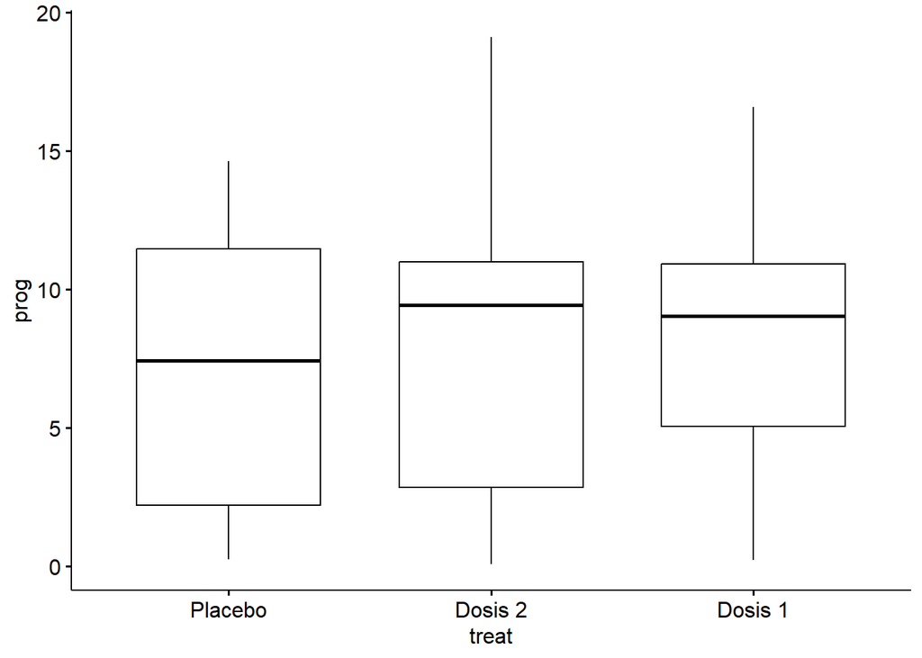

```r
datos_maca %>%
  filter(time == "3 months") %>%
  ggboxplot(x = "treat", y = "prog")
```

### Ejercicio 3

Explore si la distribución de progesterona en cada nivel de tratamiento se aproxima a una nuermal mediante gráficos quantile quantile. También explore la posibilidad de heterogeneida de varianzas:

**Solución**

- Normalidad:

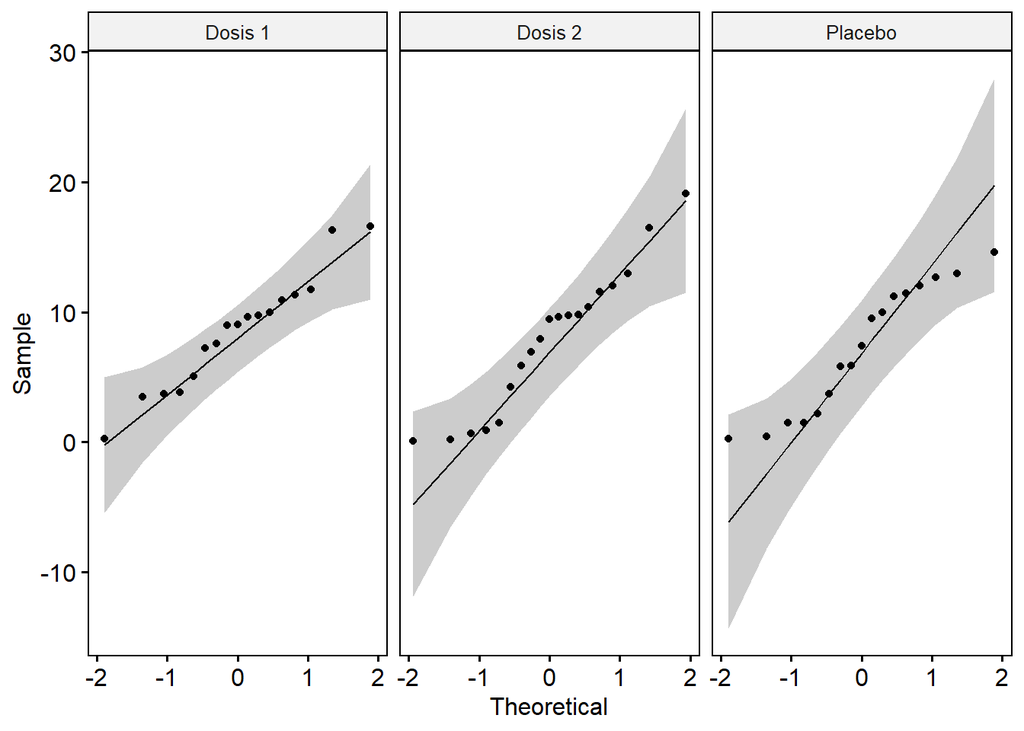

```r
datos_maca %>%
  filter(time == "3 months") %>%
  ggqqplot("prog", facet.by = "treat")
```

- Heterogeneidad de varianzas:

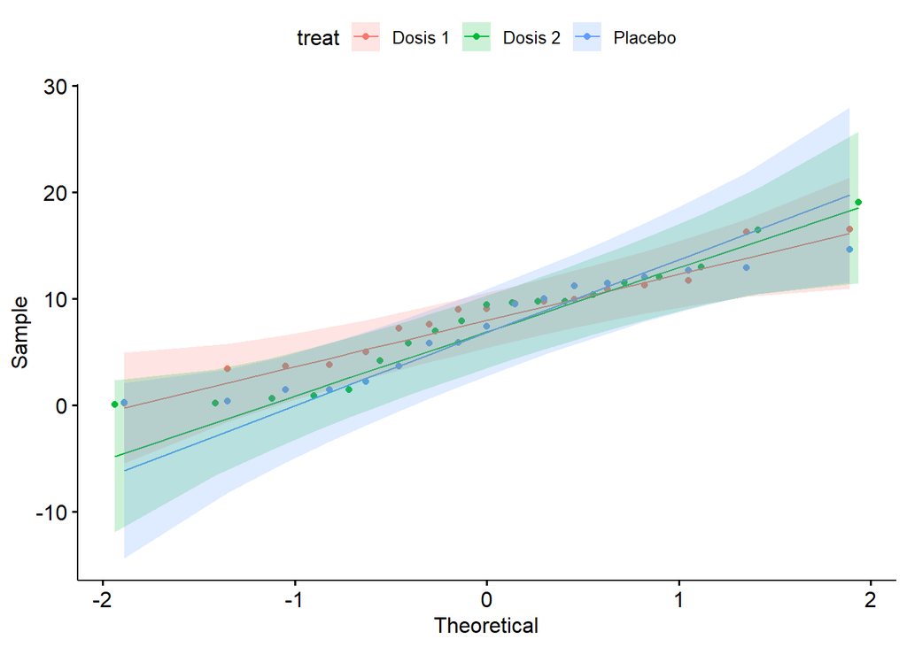

```r
datos_maca %>%
  filter(time == "3 months") %>%
  ggqqplot("prog", color = "treat")
```

- El paralelismo de las graficas qqnorm refleja “homogeneidad de varianzas”. Si, en cambio, no son paralelas y se intercecan, cuanto más pronunciada la intersección de ambas, más evidencia gráfica de “heterogeneidad de varianzas”.
- Otra opcion es inspeccionar varianzas y compararlas.
- Pruebas de hipótesis también existen, aunque hay controversias sobre su uso aislado.

### Ejercicio 4

Evalúe si existe un efecto del tratamiento sobre progesterona al final del estudio mediante un ANOVA de una via. Evalúe los supuestos.

*¿Cómo interpretarías los resultados encontrados? (discutirlo en la sesión)*

**Solución**

```r
datos_maca %>%
  filter(time == "3 months") %>%
  anova_test(prog ~ treat, detailed = TRUE)
```

```
ANOVA Table (type II tests)

  Effect    SSn      SSd DFn DFd     F     p p<.05   ges
1  treat 14.442 1254.167   2  50 0.288 0.751       0.011
```

# 3 Parte 2

En esta parte taller, exploraremos un experimento completamente aleatorizado que compara dos brazos de tratamiento: uno tratado y otro placebo. El objetivo es comparar la incidencia acumulada de diabetes y eventos adversos graves entre los dos grupos. Ambos desenlaces son binarios, lo que significa que podemos utilizar pruebas estadísticas adecuadas para analizar los datos. Para este taller, nos centraremos en el uso de la prueba de chi cuadrado de homogeneidad para evaluar la asociación entre el tratamiento y la incidencia de diabetes.

## 3.1 Cargar datos

Primero, cargaremos los datos necesarios para el análisis. Utilizaremos un data.frame que contiene los dos desenlaces: incidencia de diabetes y eventos adversos graves.

```r
data <- import("ensayo_diabetes.rds")
```

En este data.frame, la columna “tratamiento” indica el brazo de tratamiento asignado a cada individuo, la columna “diabetes” indica si el individuo desarrolló diabetes (1) o no (0), y la columna “eventos_adversos” indica si el individuo experimentó un evento adverso grave (1) o no (0).

## Ejercicio 1

Presente una tabla de contingencia del tratamiento y diabetes y del tratamiento y eventos adversos:

**Solución**

```r
data %>%
  tabyl(tratamiento, diabetes)
```

```
 tratamiento no si
     Placebo 36 14
     Tratado 15 35
```

## Ejercicio 2

Realice una prueba de chi-cuadrado de homogeneidad para evaluar la asociación entre el tratamiento y la incidencia acumulada de diabetes.

**Solución**

```r
data %>%
  tabyl(tratamiento, diabetes) %>%
  select(-1) %>%
  chisq_test()
```

```
# A tibble: 1 × 6
      n statistic         p    df method          p.signif
* <dbl>     <dbl>     <dbl> <int> <chr>           <chr>
1   100      16.0 0.0000631     1 Chi-square test ****
```

- Veamos el supuesto de frecuencais esperadas:

```r
data %>%
  tabyl(tratamiento, diabetes) %>%
  select(-1) %>%
  chisq_test() %>%
  chisq_descriptives()
```

```
# A tibble: 4 × 9
  Var1  Var2  observed  prop row.prop col.prop expected resid std.resid
  <fct> <fct>    <dbl> <dbl>    <dbl>    <dbl>    <dbl> <dbl>     <dbl>
1 A     no          36  0.36     0.72    0.706     25.5  2.08      4.20
2 B     no          15  0.15     0.3     0.294     25.5 -2.08     -4.20
3 A     si          14  0.14     0.28    0.286     24.5 -2.12     -4.20
4 B     si          35  0.35     0.7     0.714     24.5  2.12      4.20
```

## Ejercicio 3

Realice una prueba de chi-cuadrado de homogeneidad para evaluar la asociación entre el tratamiento y la incidencia acumulada de eventos adversos serios.

**Solución**

- Veamos la tabal de contingencia primero:

```r
data %>%
  tabyl(tratamiento, eventos_adversos)
```

```
 tratamiento no si
     Placebo 33 17
     Tratado 29 21
```

```r
data %>%
  tabyl(tratamiento, eventos_adversos) %>%
  select(-1) %>%
  chisq_test()
```

```
# A tibble: 1 × 6
      n statistic     p    df method          p.signif
* <dbl>     <dbl> <dbl> <int> <chr>           <chr>
1   100     0.382 0.537     1 Chi-square test ns
```

- Veamos el supuesto de frecuencais esperadas:

```r
data %>%
  tabyl(tratamiento, eventos_adversos) %>%
  select(-1) %>%
  chisq_test() %>%
  chisq_descriptives()
```

```
# A tibble: 4 × 9
  Var1  Var2  observed  prop row.prop col.prop expected  resid std.resid
  <fct> <fct>    <dbl> <dbl>    <dbl>    <dbl>    <dbl>  <dbl>     <dbl>
1 A     no          33  0.33     0.66    0.532       31  0.359     0.824
2 B     no          29  0.29     0.58    0.468       31 -0.359    -0.824
3 A     si          17  0.17     0.34    0.447       19 -0.459    -0.824
4 B     si          21  0.21     0.42    0.553       19  0.459     0.824
```

## Ejercicio 4

Con la tabla de contingencia del problema anterior, aplique la prueba de proporción y la prueba de fisher. Interprete los IC95%

**Solución**

- Veamos la tabal de contingencia primero:

```r
data %>%
  tabyl(tratamiento, eventos_adversos)
```

```
 tratamiento no si
     Placebo 33 17
     Tratado 29 21
```

- Prueba de proporción:

```r
data %>%
  tabyl(tratamiento, eventos_adversos) %>%
  select(-1) %>%
  prop_test(detailed = TRUE)
```

```
# A tibble: 1 × 13
      n    n1    n2 estimate1 estimate2 statistic     p    df conf.low conf.high
* <dbl> <dbl> <dbl>     <dbl>     <dbl>     <dbl> <dbl> <dbl>    <dbl>     <dbl>
1   100    50    50      0.66      0.58     0.382 0.537     1   -0.130     0.290
# ℹ 3 more variables: method <chr>, alternative <chr>, p.signif <chr>
```

- Prueba de Fisher

```r
data %>%
  tabyl(tratamiento, eventos_adversos) %>%
  select(-1) %>%
  fisher_test()
```

```
# A tibble: 1 × 3
      n     p p.signif
* <dbl> <dbl> <chr>
1   100 0.537 ns
```